# Chapter D3 構造設計におけるいくつかの重要詳細

執筆：ウィリアム・F・マコームズ （設計スペシャリスト - チャンス・ヴォート社）

## D3.1 はじめに

航空機の設計および製造において、主要な構成部品は徹底的なレビューと評価を受ける。しかし、多くの小さな部品は土壇場で設計されることがあり、あまり注意を払われないため、設計上の欠陥を抱えていることがある。サービス中やテスト中に頻繁に問題を引き起こすのは、これらの部品である。本章では、なぜか見落とされがちな、より一般的な設計詳細のいくつかについて指摘することを試みる。これは、航空機や類似の構造物の構造部材の設計や対処に携わる人々にとって有益な情報となるはずである。具体的な詳細については、多くの航空機メーカーが独自の標準設計手法を定めている。読者は、利用可能であれば常に自社のデータを参照すべきである。それらが利用できない場合には、以下に推奨する手法が実用的な助けとなるだろう。

## D3.2 せん断クリップ（Shear Clips）

典型的な軍用機には、数百ものせん断クリップが使用されている。これらは、主要な構造部材同士を結合するだけでなく、機器取付ブラケットなどの二次的な構造部品を結合するためにも使用される。せん断クリップの機能は、ある部材から別の部材へせん断荷重を伝達することである。軸荷重、曲げモーメント、またはねじりを伝達するようには意図されておらず、せん断荷重のみを伝達する。

代表的な例を Fig. D3.1 に示す。ここでは、ブラケットまたは梁 (a) が、梁 (b) および (c) によって支持されている。荷重 $P$ は、図示されているように、クリップを介して (b) および (c) のウェブへせん断荷重として伝達され、(b) および (c) へ「梁のように分散」される。

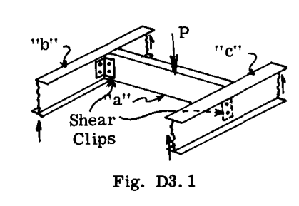

Fig. D3.1

重大な軸荷重や曲げモーメントも伝達しなければならない場合は、追加の部材を設けるか、せん断クリップをより頑丈なフィッティングに交換する必要がある。これを Fig. D3.2 に示す。ここでは、梁 (a) が重い構造部材 (b) から片持ち梁のように突き出している。荷重 $P$ は、せん断荷重としてウェブ (a) から (b) へせん断クリップを介して伝達される。また、伝達すべき曲げモーメント $P \times l$ も存在する。この目的のために、追加の継手プレート “S” が設けられている。これらは、梁 (a) のフランジからの軸荷重の形でモーメントを部材 (b) へ伝達する。

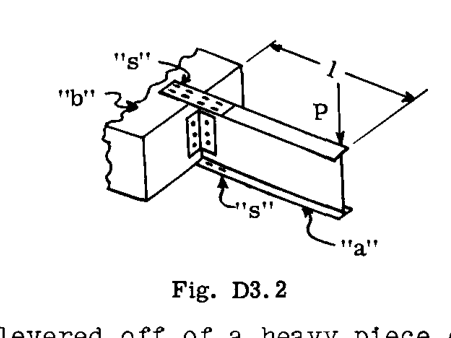

Fig. D3.2

せん断クリップは通常、次の2つの形式で見られる。

1. 曲げ加工された板金または押し出しアングル（脚と脚の間の角度は $0^\circ$ から $180^\circ$ の間）。
2. 押し出し “T” 字材。

これらのせん断クリップの「最小限許容できる」形式を Fig. D3.3 に示す。

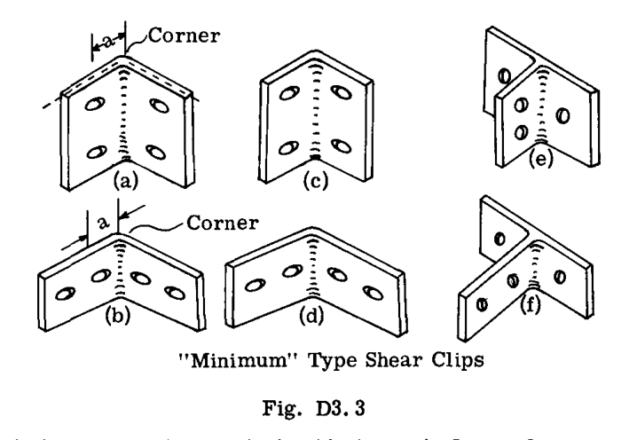

Fig. D3.3

最小限の要件として、アングル型クリップの各脚には、それを貫通する少なくとも2つの留め具（ファスナー）が必要である。T字型クリップの「頭部」およびその脚にも、(e) および (f) に示すように、それぞれ少なくとも2つの留め具が必要である。

アングル型せん断クリップの荷重の「バランス」を Fig. D3.4 に示す。クリップのコーナーエッジは、伝達されるせん断荷重（この図では $1000\text{ lb}$ とする）のみを負担すると仮定すべきである。留め具に作用する純荷重は、図示のようになる。荷重が判明すれば、標準的な手法を用いてクリップと留め具の強度を検証することができる。

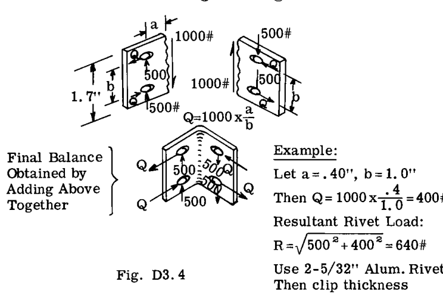

Fig. D3.4

$$\text{例：}
\\
\text{a} = 0.40"\text{、b} = 1.0"
\\
\text{このとき、} Q = 1000 \times \frac{0.4}{1.0} = 400\#
\\
\text{合力リベット荷重：}
\\
R = \sqrt{500^2 + 400^2} = 640\#
\\
2-5/32" \text{アルミ製リベットを使用}
\\
\text{必要なクリップ厚さ } t = 0.032"\text{、75ST Alc.}$$

Fig. D3.5 は、アングルクリップの片方の脚に留め具が1つしか設けられていない場合に何が起こるかを示している。単一の留め具は、（摩擦を無視すると）コーナーにおけるいかなるせん断力ともバランスを取ることができない。言い換えれば、それが固定されているウェブからのせん断力しか受けることができない。これにより、クリップのもう一方の脚に、したがって結合されるもう一方のウェブに、ねじり $P \times a$ が発生する。当然のことながら、これは許容できない。なぜなら、ねじりを負担するためにはるかに厚い脚が必要となり、結合されるもう一方のウェブに過度なねじれが生じるからである。もちろん、スペースが許せば、2つだけでなく複数の留め具を使用することができる。

Fig. D3.3 におけるタイプ (a)、(c)、(e) のクリップは、タイプ (b)、(d)、(f) よりも効率的である。後者は、スペースの制限からそれしか許容されない場合に使用される。すべての場合において、寸法 “a” は実用的な取り付けが許す限り小さく保つべきである。

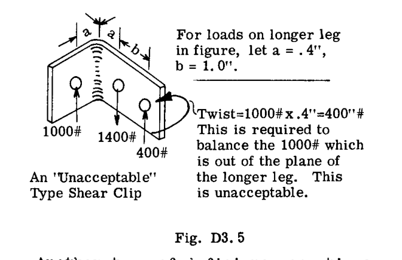

Fig. D3.5

最小限のタイプのせん断クリップを使用している場合に、別のタイプの不具合が生じることがある。これを Fig. D3.6 に示す。ここでは、アングルクリップの一方の脚を、取り付けられる部材の局所的に厚い部分を避けるために「ジョグル（段曲げ）」する必要があった。ジョグルが著しい場合、例えばクリップの厚みと同等以上である場合、クリップの剛性が大幅に低下し、前述の好ましくないねじれ効果を伴う2つの「1本リベットクリップ」として機能してしまう可能性がある。この場合、剛性と適切な機能を維持するために、Fig. D3.6(b) に示すように、ジョグルされた脚のジョグルの一方の側に少なくとも2つの留め具を設ける必要がある。荷重は、Fig. D3.3 のケース (b) または (d) と同様に、ジョグルの上にある2つの留め具によって支持されると仮定すべきである。ジョグルについては、D3.4節でさらに詳しく説明する。

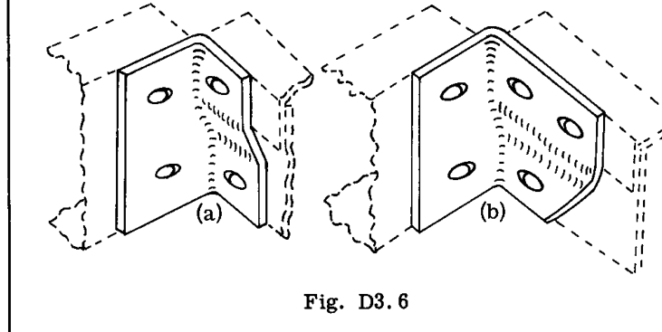

Fig. D3.6

## D3.3 引張クリップ（Tension Clips）

これらも軍用機において非常に数多く存在し、ある部材から別の部材へ比較的軽い引張荷重を伝達するために使用される。引張クリップは、非常に効率の悪いタイプの継手である。特に疲労寿命が比較的劣っているため、荷重が小さく、他の設計要因によってより効率的な重ね合わせせん断継手（ラップジョイント）の使用が妨げられる場合にのみ使用すべきである。

これは通常、バルクヘッドのウェブやフランジ、あるいはフィッティングなどの構造部材を効率よく「切り開く」ことができず、軸荷重を受ける部材を貫通させられない場合に採用される。また、片持ちブラケットをバルクヘッドや肋材（リブ）、その他の構造物に取り付けるためにも頻繁に使用される。

Fig. D3.7 を考える。部材 (a) は、例えばバルクヘッドの一方の側にあり、もう一方の側にある部材 (b) と結合される。伝達すべき軸方向の引張荷重があり、バルクヘッドを切断できないため、図示のような引張クリップ配置を使用しなければならない。この例ではアングルクリップが示されている。

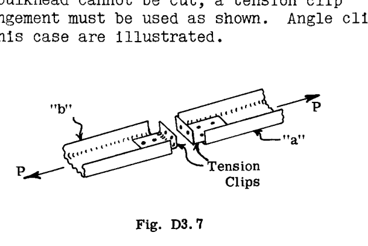

Fig. D3.7

シンプルな引張クリップは比較的軽い荷重に使用され、大きな荷重には「バスタブ」タイプの機械加工されたフィッティングが必要となる。これらのクリップは通常、次の3つの形式で見られる。

1. シングルアングル - 板金を曲げ加工したもの、または押し出し材。
2. ダブルアングル（背合わせ）。
3. 押し出しT字セクションから切り出したクリップ。

特定の厚さに対して、タイプ (c) が最も強度が高く、剛性も最大である。

最大の強度と剛性を得るためには、取り付けにボルトを使用すべきである。図示されたシングルアングルクリップ配置の許容荷重データを Fig. D3.8 に示す。許容荷重を求める方法も、図中の破線で示されている。

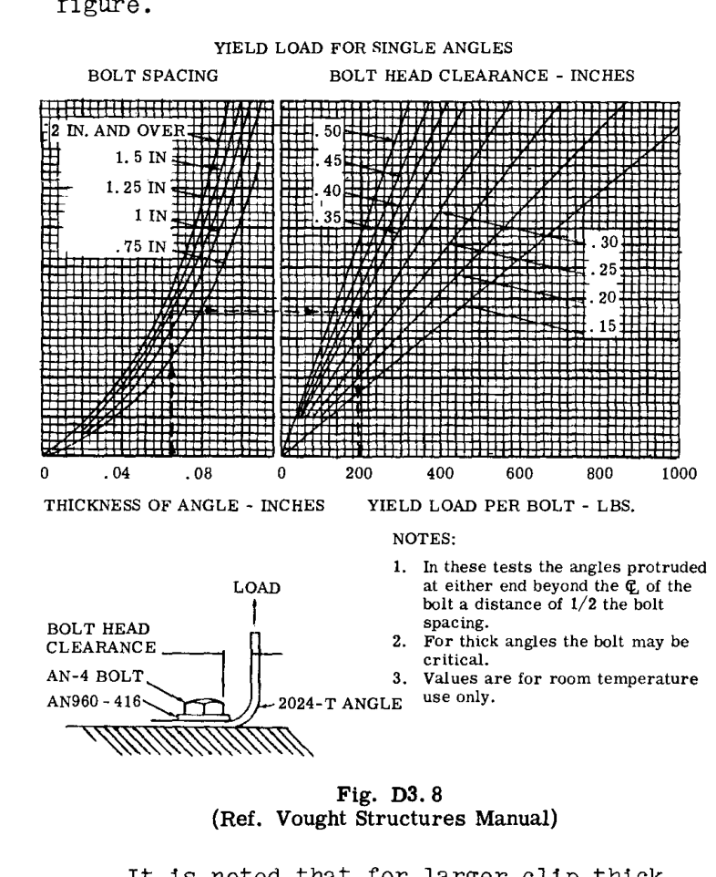

Fig. D3.8

クリップの厚さが大きくなると、ボルトが臨界状態に達して降伏し始める可能性があることに注意されたい（図示された厚さに対して、指定されたボルトより小さいボルトを使用した場合も同様である）。これは、ボルトに対する「こじり作用（プライイング作用）」によるものである。こじり作用のため、ボルトに作用する荷重は常に適用荷重よりも大きくなる。アングル型クリップの配置を示す Fig. D3.9(a) を考える。適用荷重 $P$ がクリップを「開き」始めると、ボルトは増加する引張荷重 $Q$ を受け、クリップの「つま先（トウ）」は互いに強く押し付け合う。静力学から、トウの圧力中心まわりのモーメントをとると、次式のようになる。

$$Q = P \times \left( \frac{a+b}{a} \right)$$

したがって、 $Q$ は $P$ よりも大きくなる。明らかに、十分に小さなボルトは、厚いクリップがワッシャーの近くで曲げ降伏または破断する前に、引張で降伏または破断する（ $M_{\text{clip}} = P \times e$ ）。また、図示されているように、T字型クリップにもこじり作用が存在する。

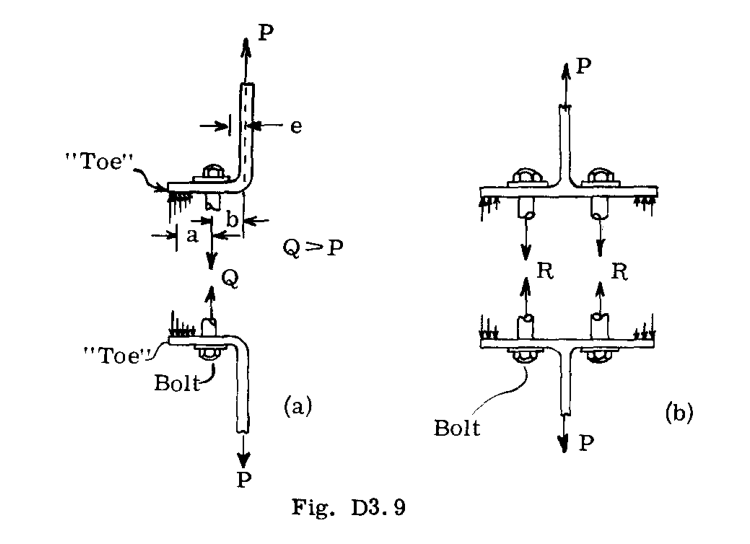

Fig. D3.9

このこじり作用こそが、設計者が軽い引張荷重に対してさえも、時折行われるようにリベットを使用することに慎重であるべき理由である。リベットを使用する場合（機器取付ブラケットの取り付けなど）は、スチール製のリベットを使用し、こじり荷重を慎重にチェックして、十分な安全マージンを維持することが最善である。いずれにせよ、リベット留めされたクリップは劣っており、それらに対する設計データはここには示されていない。

引張クリップを使用する際、もう一つのポイントが頻繁に見落とされる。クリップが取り付けられる構造は、そこに作用する荷重を負担できなければならない。これらの荷重は、ボルトからの引張荷重と、つま先の作用からの荷重で構成される。いくつかの例を Fig. D3.10 に示す。これらの例において「許容不可」という用語は、Fig. D3.8 の許容荷重が適用できないことを意味する。

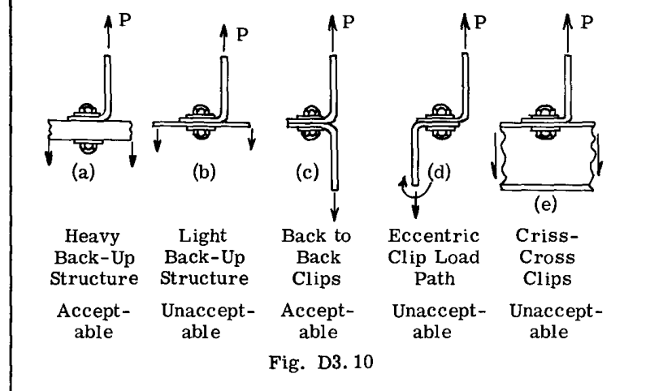

Fig. D3.10

ケース (b)、(d)、および (e) では、クリップからの荷重を受け止めるために、裏打ち構造（バックアップ構造）の再配置または追加の構造が必要となる。これにより Fig. D3.8 の全許容値が達成される。裏打ち構造にかかる合力は、当然ながら適用されたベクトル $P$ である。

引張クリップは、静的強度と剛性が低いだけでなく、疲労寿命も比較的短い。荷重が、引き起こし（プルアップ）や突風などの対称飛行状態によって何度も発生するような性質のものである場合、制限荷重レベルにおいて200%以上の大きな安全マージンを確保すべきである。荷重が、衝突状態やシステムジャム荷重のような、繰り返しのない単発の荷重に起因するものである場合、このような大きな安全マージンは必要ない。

引張クリップに関するその他の推奨事項は以下の通りである。

1. ボルト頭は、可能な限り曲げ半径やフィレット半径の近くに配置する。
2. 繰り返し荷重が支配的な場合は、可能であればその使用を避ける。
3. 構造の一部がジョイントを横切って連続しており、一部が遮断されている場合、遮断された構造の結合に引張クリップを使用せず、代わりに、より重く剛性の高い機械加工されたフィッティングを使用する。

## D3.4 ジョグル部材（Joggled Members）

「ジョグル」とは、部材に形成されるオフセット（段差）のことである。通常、オープン断面タイプの部材の1つまたは複数のフランジに関係する。ジョグルは、典型的な金属製航空機構造において非常に一般的である。これらは、ジョイントに追加の部品を使用せずに、交差する2つの部材を結合したい場合に最もよく使用される。ジョグルは妥協策である。追加の部品を節約できるが、その代償としてジョグルされた部材の強度と剛性が低下する。ジョイント部における部材の荷重が十分に小さければ、この節約は正当化される。そうでない場合は、ジョグルの代わりに、またはジョグルに加えて、追加の部品を使用しなければならない。代表的なジョグル取付を Fig. D3.11 に示す。ここでは、アングル部材の一方の脚が別の同一平面上の部材をまたいでジョグルされ、そこに固定されている。

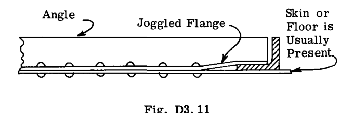

Fig. D3.11

一部の航空機メーカーは、ジョグル部材の設計に関する具体的な強度データや慣行を定めている。これらは、利用可能であれば当然設計者によって参照されるべきである。メーカーによっては、ジョグルの長さ対深さの比率として 6:1 を使用するところもあれば、3:1 を使用するところもあり、あるいはその両方が使用されることもある。ある比率の強度や剛性のデータを、別の比率に盲目的に適用すべきではない。これらのデータの一部は、アングル部材の場合、ジョグルの深さがジョグルされた脚の厚さと同等かそれ以上になると、強度の低下が、曲げ半径の外側にある脚の消失とほぼ等しくなることを示している。したがって、以下のような「経験則」による設計手法が提案されている。

強度および剛性の観点から、ジョグルの実質的な効果は、ジョグルされた脚に、曲げ半径の接点まで内側に切り込まれた「スロット（切り欠き）」と同等であると仮定する。これを Fig. D3.12 に示す。

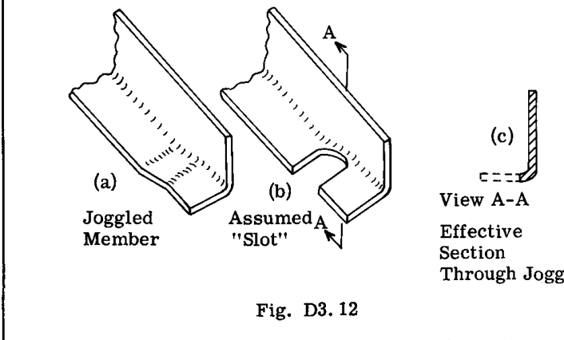

Fig. D3.12

この仮定により、ジョグルされた脚の平坦な部分は、ジョグル領域を横切る軸荷重を一切負担しないが、湾曲した要素に対して支持を提供することになる。有効純断面 Fig. D3.12(c) は、作用する任意の力に対して標準的な解析手法を用いて検証することができる。図示された純断面は、残された脚に対して垂直な曲げモーメントを負担する強度がほとんどないことは明らかである。したがって、軸荷重が可能な限りコーナーの近くに導入されるように注意を払う必要があり、これはつまり、ジョグルの各側に少なくとも2つの留め具を使用すべきであることを意味している。

上記の、ジョグルをスロットと同等とみなすアプローチは、設計者がジョグル部材を指定する際に、自分が実際に何を行っているかをよりよく「実感」するのに役立つ。強度と剛性が失われる根本的な理由は Fig. D3.13 に見ることができる。

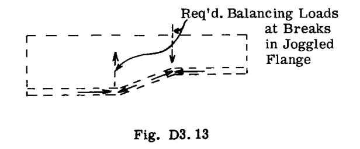

Fig. D3.13

ジョグルされた脚の軸荷重は、互いに傾斜しているため、バランス荷重を必要とする。薄い脚内のせん断力以外にこのようなバランス荷重は得られないため、剛性と強度の低下を招く。T字型部材の対称な脚がジョグルされている場合は、アングルの場合よりも剛性が高くなるが、試験データがない場合は、より保守的ではあるが同様のアプローチが推奨される。

前述の議論の例として、アングル部材が、Fig. D3.14 に示すように力 $Q$ によって局所的に荷重を受ける別の部材を支持していると仮定する。外板（スキン）が存在する場合、図示のように、外板のガセット効果によって荷重の一部をジョグルを横切って伝達させることができる。これは、別の章で説明されている外板の間リベット座屈の計算手法を用いて近似することができる。荷重の残りの部分は、ジョグル領域におけるアングルの有効純断面によって伝達されなければならない。

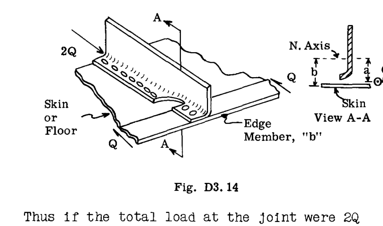

Fig. D3.14

したがって、ジョイントにおける全荷重が $2Q$ であり、外板の荷重負担能力が $R$ である場合、アングルの純断面は荷重 $P = 2Q - R$ および曲げモーメント $M = 2Q \times a - R \times b$ を受けることになる。下側の湾曲したエッジにおける応力は、圧縮応力の合計となる。

$$f_c = \frac{MC}{I_{\text{Net Section}}} + \frac{P}{A_{\text{Net
Section}}}$$

極限強度に対して、一般的なケースでは保守的に $f_c$ を $F_{cy}$ まで許容することができる。

最大の強度と剛性を実現するためには、純断面の荷重を「コーナー」に作用させなければならない。これは、残された脚の平面から外れる曲げによる応力を防ぐためである。このため、ジョイント部において荷重を受けるために、最小限2つの留め具を設けることが要求される。ここでの理由は、最小限のタイプのせん断クリップに関してD3.2節で議論したものと同じであり、留め具の荷重はそこで説明されたのと同様の方法で計算することができる。

荷重が純断面で支えるには大きすぎる場合は、局所的に追加の部材を設けるべきである。これを行うための2つの方法を Fig. D3.15 に示す。

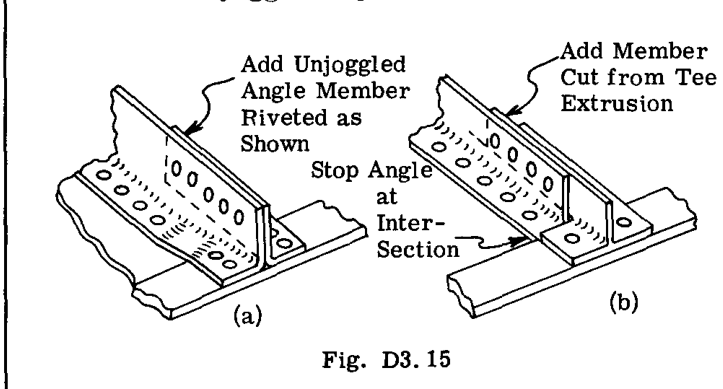

Fig. D3.15

局所的な要件により、アングル部材の両方の脚をジョグルする必要が生じることがある。そのような場合、アングルはジョグル部において有意な荷重負担能力を持たないと仮定すべきである。したがって、ジョイント部に有意な荷重が存在する場合は追加の部材が必要となり、アングルはジョグルして上に乗せるのではなく、ジョイントの手前で終了させるべきである。

他のタイプの断面を持つ部材の提案される有効純断面を Fig. D3.16 に示す（点線で示された脚がジョグルされている）。一般に、ジョグルがわずかであり、ジョグルされた脚の厚さよりもかなり小さい場合は、その影響を無視することができるが、議論されたように適切な留め具は依然として設けるべきである。ジョグルの長さ対深さの比率が小さいほど、ジョグルの影響は大きくなる。ジョグルされた部材は、引張荷重および圧縮荷重を受けたときに剛性と強度が低下する（ただし、存在する外板は、圧縮時よりもガセットとして機能する際に当然ながらはるかに効果的である）。

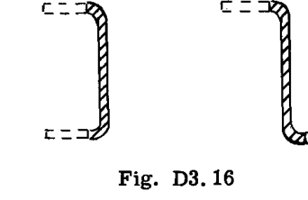

Fig. D3.16

## D3.5 フィラー（Fillers、隙間材）

その名の通り、フィラーは隙間を埋めるために使用される。フィラーが構造的な荷重経路の一部となる場合、特別な注意が必要である。フィラーは、典型的な大型または複雑な金属製航空機構造において非常に一般的なアイテムでもある。

一例として Fig. D3.17 を考える。ここでは、軸荷重 $P$ を伝える2つのT字材 “a” と “b” が、一対のアングル “c” によってスプライス（結合）されている。“b” の下側の脚は “a” の脚よりも厚いため、フィラーが必要となる。このフィラーは、“c” から “a” への構造荷重経路の一部である。このケースにおいて、留め具の全強度を発揮させるためには、フィラーを「延長」し、その延長された部分を部材 “a” に結合するための追加の留め具を設けなければならない。これが行われない場合、それは「フローティング（浮動）」フィラーと呼ばれる。後述するように、フローティングフィラーは、十分に厚い場合、留め具の強度低下を引き起こす。

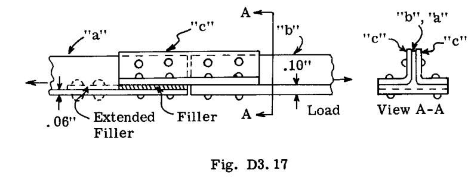

Fig. D3.17

上記の例において、全荷重 $P$ を $8000\text{ lb}$ とし、このうち $2000\text{ lb}$ がフィラー領域の2つの留め具によって “c” から “a” へ伝達されなければならないと仮定する。支圧によってフィラーに加わる荷重の部分は、次のようにとることができる。

$$P_{\text{Filler}} = P_{\text{Fasteners}} \times
\frac{t_{\text{Filler}}}{t_{\text{Filler}} + t_a}$$

$$= 2000 \times \frac{0.04}{0.04 + 0.06} = 800\text{ lb.}$$

この $800\text{ lb}$ を部材 “a” に伝達するために、フィラーの延長部分に十分な留め具を配置すべきである。

このように、せん断でスプライスされる2つの部材の間に厚いフィラーが挿入される場合は常に、フィラーはいずれか一方の部材と一体であると仮定すべきである。フィラーが負担する全スプライス荷重の一部は、上記のように計算することができる。その後、留め具は2つのグループに分けて考えることができる。一方のグループは、単一の部材から「フィラー＋部材」の組み合わせへの全せん断荷重をスプライスするための強度を持たなければならない。もう一方のグループの留め具は、計算されたフィラー荷重を、それが一体であると仮定される部材に伝達するための強度（せん断および支圧）を持たなければならない。別の例を Fig. D3.18 に示す。

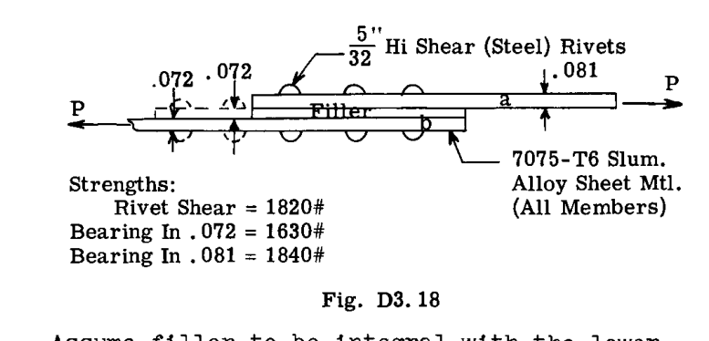

Fig. D3.18

フィラーが下側の部材 “b” と一体であると仮定する。

### ケース I

$$P = 3000\text{ lbs.}$$

1. “a” から “b” とフィラーの組み合わせへ $3000\text{ lbs.}$ をスプライスするのに必要なリベット数：

$$\text{リベット数} = \frac{3000}{1820} = 1.65\text{、または } 2$$

2. フィラーによって負担される荷重（“b” へスプライスされるもの）：

$$P_{\text{Filler}} = 3000 \times \frac{t_F}{t_F + t_b} = 3000 \times
\frac{0.072}{0.072 + 0.072} = 1500\text{ lbs.}$$

3. 荷重 $P_F$ を “b” へ伝達するのに必要な留め具：

$$\text{留め具数} = \frac{1500}{1630} = 0.92\text{、または } 1$$

$$\text{必要な総留め具数} = 2 + 1 = 3\text{.}$$

3本のリベットが存在するため、スプライスは適切である。フィラーが存在しなかった場合、2つの留め具で十分であった。

### ケース II

$$P = 5000\text{ lbs.}$$

ケース I と同様の手順を繰り返す：

1. 必要なリベット数：

$$\text{必要なリベット数} = \frac{5000}{1820} = 2.75\text{、または } 3$$

2. フィラーの荷重：

$$\text{フィラーの荷重} = 5000 \times \frac{0.072}{0.072 + 0.072} =
2500\text{ lbs.}$$

3. 必要なリベット数：

$$\text{必要なリベット数} = \frac{2500}{1630} = 1.54\text{、または } 2$$

したがって、荷重 $P$ を “a” から伝達するために3本のリベットが必要であり、フィラーの荷重を部材 “b” へ逃がすためにさらに2本のリベットが必要となる。フィラーは “b” の上に延長されるべきであり、Fig. D3.18 に点線で示されているように、2つの追加の留め具を追加する必要がある。

確かに、上記の手順は近似的であるが、フィラーの影響を迅速に評価する方法を提供する。フィラーの厚さが留め具直径の約15%未満である場合、その存在は無視することができる。

フィラーの影響は、留め具の許容強度を低下させることである。この理由は Fig. D3.19 から理解できる。フィラーの存在は、せん断荷重とともに、より大きなこじり荷重を引き起こし、したがって留め具により多くの引張力を発生させる。

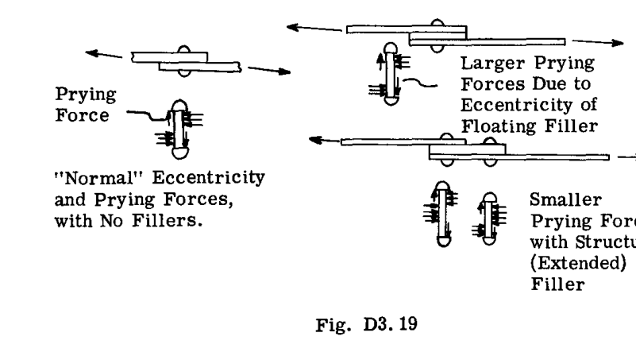

Fig. D3.19

構造的な荷重経路におけるいかなるフィラーも、当然ながら、その周囲の構造と剛性において適合する材料で作られるべきである。すなわち、高度に熱処理された鋼製部品の間に軟質アルミニウム製フィラーを使用したり、アルミニウム製部品の間にフェノール樹脂やグラスファイバー製フィラーを使用したりすべきではない。フィラーの必要性は、設計上の考慮事項からだけでなく、製造上の問題からも頻繁に生じる。後者のケースでは、組立時に部品間の「ミスマッチ」が時折発生する。高価な手直しを防ぐために、結合領域を適切にするために構造用フィラーを使用しなければならない。これらのケースでは、詳細な注意が必要である。フローティングフィラーを避けられない稀なケースにおいて、フィラーがかなりの厚さである場合、留め具は局所的に伝達されるせん断力を十分に上回る定格許容値を持たなければならない。フィラーを取り付ける際に、留め具に加えて接着剤（グルー）を使用することも一般的な慣行である。

## D3.6 ウェブまたは外板パネルにおけるカットアウト（Cut-outs in Webs or Skin Panels）

航空機構造は、アクセスを提供するため、またはコントロールロッド、油圧ライン、電気ワイヤー束などの他の部材を通過させるために、ウェブやパネルを開口する必要性に絶えず直面している。設計者や連絡エンジニアは、構造的に健全なカットアウトを提供するための様々な方法のいくつかに精通している必要がある。

カットアウトを設ける方法はいくつかある。ここでは次の3つを取り上げる。

1. カットアウトの周囲に適切な縁材（フレーミング部材）を設ける。
2. (a)のような縁材が設けられない場合に、ダブラー（補強板）または「ベント（曲げ材）」を設ける。
3. 梁の設計に関する章で説明されている、公表された許容値を持つ標準的な丸型フランジ穴を設ける。

### (a) ウェブにおける縁材付きカットアウト（Framing Cut-Outs in Webs）

一例として、梁のウェブに Fig. D3.20 に示すようなカットアウトが必要であると仮定する。

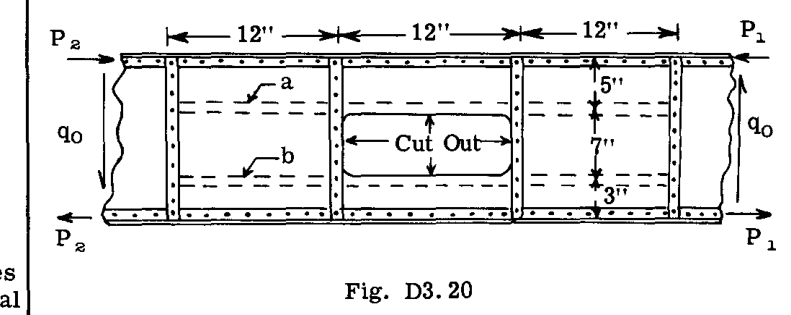

Fig. D3.20

カットアウトが施される前は、実線で示される部材（フランジ、補強材、ウェブ）が存在している。破線で示されるように、カットアウトを囲むために部材 “a” および “b” が追加される。

カットアウトの周囲に配置された領域の荷重を決定する方法は2つある。第1の方法は、カットアウトがない状態（上の図の $q_0$ ）と等しく逆向きのせん断流を仮定し、囲まれた領域における対応するバランス荷重を決定することである。この荷重システムを元のシステムに加えることで、最終的な荷重が得られ、当然ながらカットアウトパネル内では $q = 0$ となる。もう一つの方法は、カットアウトの両側で適切な割合でせん断力が負担されると仮定する標準的な手順を使用することである。ここでは第1の方法について説明する。

この議論では、すべてのせん断流は、縁部材（フランジおよび補強材上）に作用するものとして示されている。

カットアウトがなければ、Fig. D3.21a に示すように、すべてのパネルにおいて一定のせん断流 $q_0$ が存在する。次に、Fig. D3.21a の中央パネルのせん断流と等しく逆向きのせん断流が、Fig. D3.21b の中央パネルに適用される。

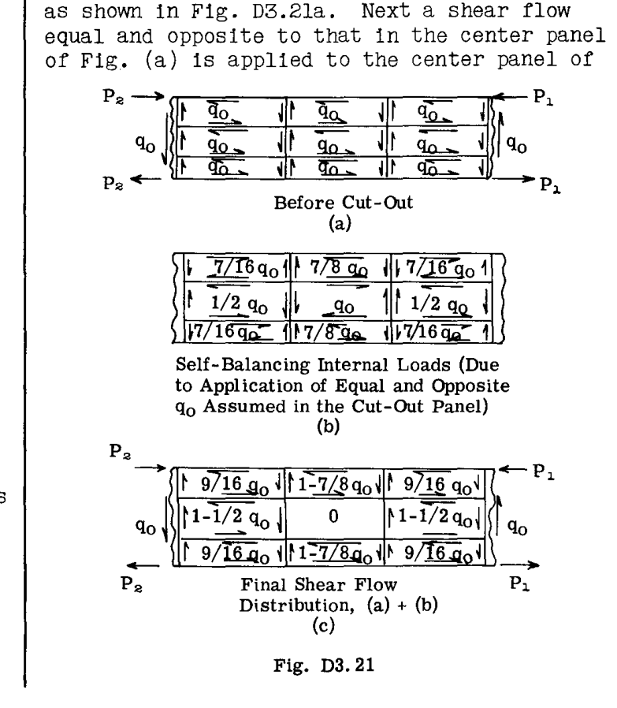

Fig. D3.21

これは自己平衡型の荷重システムを表しているため、縁取り領域の外側における外部反力は不要である。これは重要な概念であり、読者はこれについて考えるべきである。次に、(b) における $q_0$ による縁取り領域内の荷重が決定される。冗長性を排除するために、通常、カットアウトの上下のパネルには同じせん断流が存在すると仮定される。また、カットアウトの左右のパネルでもせん断流は同じであると仮定される。

$$\begin{aligned}
\text{a) } & \text{中央パネルの上下のパネルにおけるせん断流は、} q_0
\text{ による力と静的に釣り合わなければならない。} \\
& \text{すなわち、} \sum F_t = 0 \text{ より、} q_0 \times 7 = q
\times (5 + 3) \\
& q = 7/8 \, q_0 \\
\text{b) } & \text{中央パネルの左右のパネルにおけるせん断流も、} q_0
\text{ による力と静的に釣り合わなければならない。} \\
& \sum F_y = 0 \text{ より、} q_0 \times 12 = q \times (12 + 12) \\
& q = 1/2 \, q_0 \\
\text{c) } &
\text{コーナーパネルにおけるせん断流は、それらの間にある（任意の）パネルにおけるせん断流による力}
\\
&
\text{とも釣り合わなければならない。右側のベイのパネルを考慮すると、} \\
& \sum F_z = 0 \text{ より、} 1/2 \, q_0 \times 7 = q \times (5 + 3)
\\
& q = \frac{\frac{1}{2} q_0 \times 7}{8} = 7/16 \, q_0 \\
\text{d) } & \text{最終的なせん断流は、(a) と (b)
の値を代数的に加算することによって得られる。以下に注意されたい：} \\
& 1. \text{ 中央パネル（カットアウト部）のせん断流は、当然ながら } q
= q_0 - q_0 = 0 \text{ となる。} \\
& 2. \text{ カットアウトの上、下、左、右のせん断流は加算され、元の }
q_0 \text{ よりも大きな値となる。} \\
& 3. \text{ コーナーパネルにおけるせん断流は、元の } q_0 \text{
の値よりも小さくなる。} \\
&
\text{これが、カットアウトの周囲の縁取り領域において常に生じる変化の様子である。}
\\
\text{e) } &
\text{最後に、そして重要なこととして、カットアウトにより、すべての縁部材に軸荷重が発生する。}
\end{aligned}$$

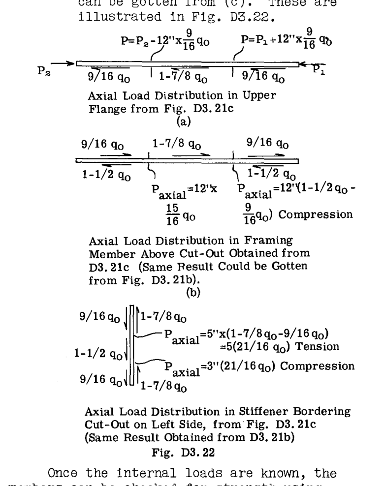

Fig. D3.22

内部荷重が判明すれば、標準的な応力解析手法を用いて部材の強度を検証することができる。

カットアウトは、縁部材をカットアウトの右側のベイまで延長することなく縁取りすることもできた。このケースを Fig. D3.23 に示す。

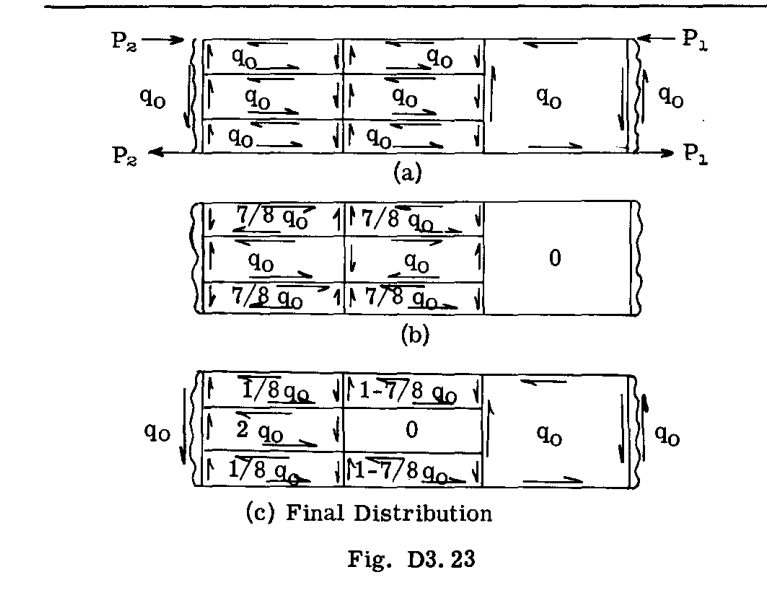

Fig. D3.23

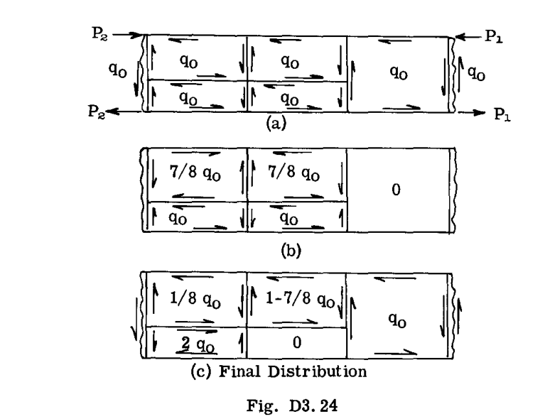

Fig. D3.24

前述の例のケース (b) において、すべての縁部材（フレーミング部材）における荷重の合計はゼロであることに注意されたい。平衡を保つための外部反力は不要である。これは、自己平衡型のせん断流システムがフラットパネル構造や、任意の側面にカットアウトを持つ3次元ボックス構造に適用される場合は常に当てはまる。読者はこれらの例を注意深く研究すべきである。この方法はフラットな梁に対してのみ示されているが、Article A21.8 のボックス梁のような、カットアウトを持つ任意の構造にも適用可能である。これは実際には同条のソリューション No. 2 に示されており、読者はこの時点でそれを復習すべきである。

前述の例で使用された梁の補強材やフランジのように、カットアウト用の縁部材が都合よく利用できない場合がある。そのような場合には、当然ながらそれらを設けなければならない。

### (b) ダブラーまたはベントによる縁取りカットアウト（Framing Cut-Outs With Doublers or Bents）

梁のウェブにおけるカットアウトは、ウェブのほぼすべてを取り除くほど深くしなければならないことが頻繁にある。この場合、前述の方法は使用できない。代わりに「力任せ（ブルートフォース）」のアプローチが必要となり、せん断力を伝達するためにカットアウトの周囲に頑丈なダブラー、またはベントが設けられる。これを Fig. D3.25 に示す。

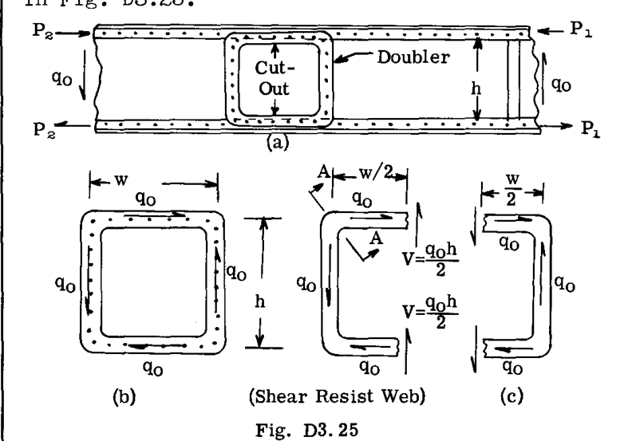

Fig. D3.25

1. に示すように、厚さがこれから決定されるダブラーが、図示のようにカットアウトの周囲に適合するように作られる。湾曲した梁の曲げによる応力を合理的な範囲に抑えるために、カットされたウェブおよびダブラーのコーナー部には合理的な内側半径が設けられる（Chapter C11 を参照）。ウェブ内の基本的なせん断流を拾い上げるために、図示のようなアタッチメントが設けられる。

ダブラーに加わる荷重を (b) に示す。すなわち、せん断流 $q_0$ である。厳密に言えば、ダブラーはフレームとして解析されるべきである。合理的な対称性があれば、(c) の荷重はフレームの中心にあると仮定することができる。すなわち、全せん断力の半分 $q_0 \times h/2$ がフレームの上部で抵抗され、半分が底部で抵抗され、カット部にはピンジョイント（曲げモーメントゼロ）が存在する。フレームの任意の断面における曲げモーメント、軸荷重、およびせん断力は、静力学の問題として導かれる。例えば、

A-A において、

$$M = V \times \frac{W}{2} = \frac{q_0 \cdot h \cdot W}{4}$$

（ $q_0$ によるわずかな緩和モーメントも存在する可能性がある）

$$F_z = V = \frac{q_0 h}{2}$$

$$F_y = q_0 \times \frac{W}{2}$$

このように、荷重を負担するために必要なダブラーの厚さは、標準的な応力解析手法を用いて決定することができる。ダブラーは、Chapter C10 で議論されているように、梁のウェブに対して単純支持を提供するために、面外方向にも十分な剛性を持つべきである。これは通常、強度目的で必要とされる厚さによって十分に提供される。

カットアウトの性質上、フレーム（ダブラー）を上部（または下部）でより深くすることができる場合がある。このような場合、より深い部分が全せん断力 $V$ のより大きな部分を負担し、より浅い部分がより小さな部分を負担すると仮定することができる。これを Fig. D3.26 に示す。ここではカットアウトが Fig. D3.25 ほど高く達しておらず、上部が全せん断の 4/5 を負担し、下部が 1/5 のみを負担すると仮定されている。

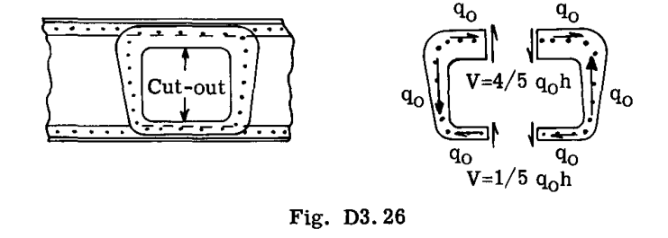

Fig. D3.26

図示されたケースは、せん断抵抗ウェブ（せん断耐力ウェブ）に対するものである。テンションフィールド（張力場）が存在する場合、ダブラーは Chapter C11 で議論されている端部ベイの効果に対しても設計されなければならない。

### (c) 標準丸型フランジ穴または「ドーナツ型ダブラー」によるアクセスの提供（Providing Access With Standard Round Flanged Holes or “Donut Doublers”）

カットアウトのサイズ要件として、標準的な丸型フランジ穴が必要な開口スペースと強度を提供できることがよくある。そのような場合、梁がせん断抵抗タイプであれば、以下のいずれかを行うことができる。

1. ウェブを局所的に、Chapter C10 で議論されている $45^\circ$ フランジを持つ標準的な丸穴を有するパネルに置き換える。
2. ウェブに必要な直径の穴を開け、上記 (1) のフランジと同等（またはそれ以上）のウェブに垂直な方向の剛性を持つ「ドーナツ型ダブラー（リング）」を取り付ける。

いずれの場合も、許容せん断力は Chapter C10 で説明されているように計算することができる。これらの許容値は丸穴にのみ適用され、フランジ付きエッジを持つ楕円形や長方形の穴には適用されない（これらは強度が劣る）。

上記項目 (2) を Fig. D3.27 に示す。Chapter C10 の穴間隔 “b” は、穴が1つしかなく、それが梁の端部近くにない場合は非常に大きくなることに注意されたい。穴間隔 “b” は、当然ながら、補強材が存在しない場合の許容せん断力を決定するために使用される。

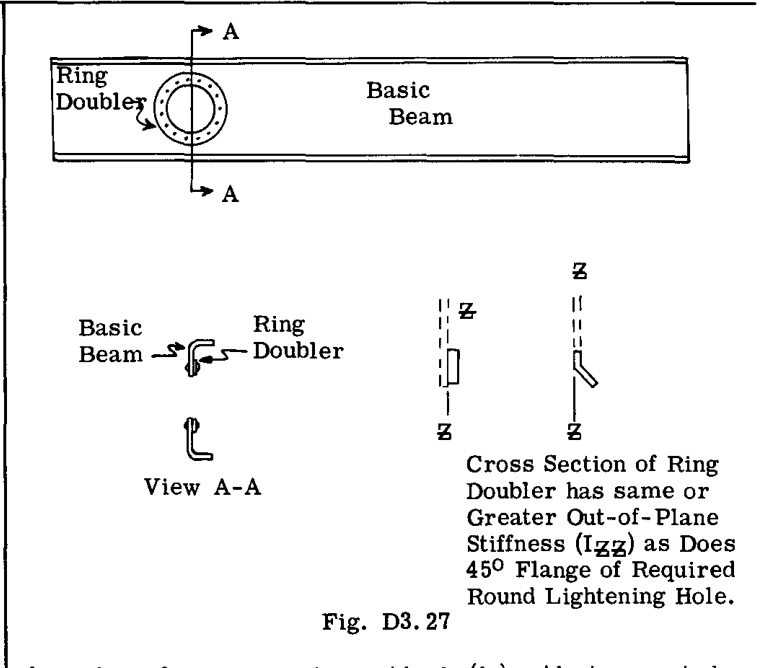

Fig. D3.27

ビード付きウェブがカットされる場合、Chapter C10 で説明されているような、ビード付きフランジを持つ穴を含むパネルを局所的に挿入することができ、これらの許容値を保守的に使用することができる。

梁がテンションフィールドタイプである場合、方法 (c) は適用されない。そのような場合には、テンションフィールド効果を負担できる、方法 (b) のようなより重いフレームを使用すべきである。

## D3.7 梁設計の特殊ケース（Special Cases of Beam Design）

Chapters C10 および C11 で説明されていない、梁の設計に関するいくつかのケースがある。これらの章は主に基本的な設計原理を提示することを目的としているためである。しかし、設計者は実務において、以下のような通常の直線梁や、バルクヘッドまたはフレームの形式の梁を含む状況に遭遇することになる。

1. 湾曲梁
2. 局所的な方向変化を持つフランジ（「折れ曲がり」フランジ）
3. フランジを曲げようとする「法線」荷重を受けるフランジ
4. ウェブの平面から外れる座屈に対して「安定化」を必要とするフランジ

### (a) 湾曲梁（Curved Beams）

Fig. D3.28 に示すような湾曲梁の一部を考える。説明のために、曲率および曲げモーメントは一定であるとする。

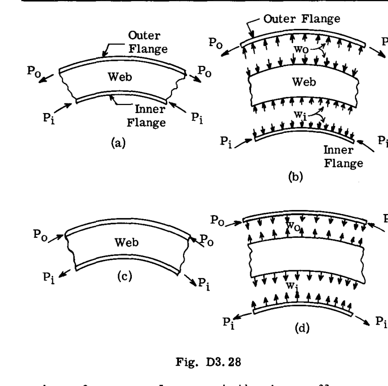

Fig. D3.28

外側（(a)における上側フランジ）が引張、内側フランジが圧縮状態にあるとき、(b) に示すように、ウェブには崩壊（圧縮）荷重が作用する。これは、フランジが互いに内側へ移動するのを防ぐために「フープ」荷重が必要となるためである。フランジ内の一定荷重 $P$ に対し、単純な静力学から次のようになる。

$$2P = 2wR$$

$$w = \frac{P}{R}$$

$w$ は、当然ながら、外側フランジよりも $R$ が小さい内側フランジにおいて大きくなる。

この圧縮荷重はウェブを崩壊させようとする傾向がある。実務でよくあるように、ウェブがせん断力も負担している場合、座屈を予測するために、圧縮応力とせん断応力を含む相互作用公式を使用すべきである。これが、Chapter C10 においてビード付きパネルやフランジ付き穴を持つパネルに対して示された許容応力が適用できない理由である。これらの許容値は、湾曲梁に存在するような法線荷重（面外荷重）がない直線ウェブに対するものであった。

曲率がウェブに重大な圧縮を引き起こすのに十分である場合、この荷重を負担するために補強材（スティフナー）を設けるべきである。これは Fig. D3.29 に示すように行うことができる。

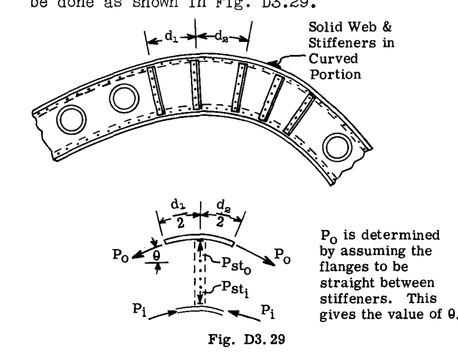

Fig. D3.29

$P_o$ および $P_i$ は、静力学から、またはバルクヘッドの内部荷重解析から決定される、補強材接合部における計算されたフランジ荷重としてとることができる。このとき、補強材の荷重は次のようになる。

$$P_{\text{st}_o} = 2P_o \tan \theta$$

$$P_{\text{st}_i} = 2P_i \tan \theta$$

補強材端部荷重のいかなる差分も、取付留め具を介してウェブへせん断力として伝達される。

フランジは、それらの中の軸荷重 $P$ に対して設計されるべきである。曲げモーメント $M$ （Fig. D3.30）に対するある程度の許容値は、中央で $M = P \times e \times 1/2$ 、補強材接合部で $-P \times e \times 1/2$ とすることで考慮できる。これらの二次的な影響は、実務において明らかに小さい場合は無視されることがある。

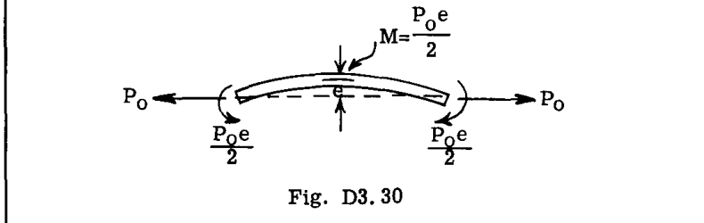

Fig. D3.30

“e” は、フランジが直線ではなく湾曲していることによる、補強材接合部間の偏心量である。内側フランジについても、この議論において圧縮状態にあることを除けば、同様のことが当てはまる。

外側フランジが圧縮、内側が引張状態にある場合、すべての荷重は Fig. D3.28(c) および (d) に示すように逆転する。このときウェブは引張荷重を受け、崩壊の問題は生じない。“通常”の理由以外に補強材は不要である。しかし、実務においては、ほとんどの荷重はある程度逆転可能であり、したがってウェブには何らかの圧縮が当然発生することになる。